# 02_behav_&_parameter_analyses

Author

Milena Musial

# 1 Preps

```r
rm(list=ls())

# install.packages('tidyverse', 'stringr')
libs<-c("tidyverse", "stringr", "plyr", "dplyr", "lme4", "robustlmm", "lmerTest",
        "sjPlot", "remef")
sapply(libs, require, character.only=TRUE)
```

```
Install package "strengejacke" from GitHub (`devtools::install_github("strengejacke/strengejacke")`) to load all sj-packages at once!
```

```
tidyverse   stringr      plyr     dplyr      lme4 robustlmm  lmerTest    sjPlot
     TRUE      TRUE      TRUE      TRUE      TRUE      TRUE      TRUE      TRUE
    remef
     TRUE
```

```r
cbPalette <- c( "#0072B2", "#D55E00", "#009E73", "#CC79A7",
                "#F0E442", "#56B4E9", "#999999", "#E69F00")


data_path<-'C:/Users/musialm/OneDrive - Charité - Universitätsmedizin Berlin/PhD/04_B01/ILT/WP2_ILT_DATA'

load(file.path(data_path,"Behav/behav_final_n71.RData"))
load(file.path(data_path,"RedCap/redcap_n71.RData"))
load(file.path(data_path,"Behav/behav_final_redcap_n71.RData"))

data_path_comp<-'C:/Users/musialm/OneDrive - Charité - Universitätsmedizin Berlin/PhD/04_B01/ILT/WP2_ILT_CODE/Stan Modeling/Output'

load(file.path(data_path_comp,"Params.RData"))

# create outcome as predictor for stay switch analyses
behav_final$outcome_pred <- factor(behav_final$outcome)
behav_final_redcap$outcome_pred <- factor(behav_final_redcap$outcome)

# code aud criteria and audit criteria as factor
#behav_final_redcap$aud_sum <- factor(behav_final_redcap$aud_sum)
#behav_final_redcap$audit_sum <- factor(behav_final_redcap$audit_sum)
#redcap$aud_sum <- factor(redcap$aud_sum)
#redcap$audit_sum <- factor(redcap$audit_sum)

# set contrasts
contrasts(behav_final$reinforcer_type) <- contr.treatment(2)
contrasts(behav_final_redcap$reinforcer_type) <- contr.treatment(2)

redcap$aud_group <- factor(redcap$aud_group, levels = c("HC", "AUD"))
contrasts(redcap$aud_group) <- contr.treatment(2)
contrasts(behav_final_redcap$aud_group) <- contr.treatment(2)

contrasts(behav_final$outcome_pred) <- contr.treatment(2)
contrasts(behav_final_redcap$outcome_pred) <- contr.treatment(2)

# se function
se <- function(x) sd(x, na.rm=TRUE)/sqrt(length(x)-sum(is.nan(x)))
```

# 2 Mandatory exclusion criteria

Exclude subjects where 2) signal loss or artefacts in MRI images were visually detected OR 3) participants exhibited translation > 4 mm or rotation > 4° across each block

```r
ID_excl <- factor()
```

# 3 Optional exclusion criteria

## 3.1 More than 10% NaN per block

```r
df_NaN <- behav_final %>%
  group_by(ID,reinforcer_type) %>%
  summarise_at(vars(rt), funs(s_NaN = sum(is.na(.)), p_NaN = sum(is.na(.))/50)) %>%
  mutate(excl_rt = p_NaN>0.1)
# add IDs to optionally excluded IDs
ID_excl <- append(ID_excl,c(df_NaN$ID[df_NaN$p_NaN>0.1]))
```

Subject 12654 has 12 % missing responses and will optionally be excluded (both blocks).

## 3.2 Same key in >95% of trials

```r
df_key <- behav_final %>%
  group_by(ID,reinforcer_type) %>%
  summarise_at(vars(side), funs(p_left = sum(side==1, na.rm=T)/50)) %>%
  mutate(excl_side = p_left>0.95)
# add IDs to optionally excluded IDs
ID_excl <- append(ID_excl,c(df_key$ID[df_key$p_left>0.95]))
```

None of the subjects pressed the same key in >95% of trials.

## 3.3 5% lowest taste ratings across blocks and participants

### 3.3.1 Prepare dfs

```r
# get df with taste and craving ratings per subject and block
behav_rating <- behav_final %>%
  group_by(ID,reinforcer_type) %>%
  select(ID,reinforcer_type,ID_block,taste1, taste2, crave1, crave2) %>%
  distinct() %>%
  mutate(taste_diff=taste2-taste1,
         crave_diff=crave2-crave1)
behav_rating <- merge(behav_rating,redcap,by="ID",all.x = T) # merge with demographic data for linear mixed-effects regression


behav_rating_alc <- behav_rating[behav_rating$reinforcer_type=='A',]
behav_rating_jui <- behav_rating[behav_rating$reinforcer_type=='J',]
```

```r
behav_rating_lowest <- behav_rating[behav_rating$taste1 < quantile(behav_rating$taste1, 0.05),]

# add IDs to optionally excluded IDs
ID_excl <- append(ID_excl,c(behav_rating_lowest$ID))
```

8 subjects have taste1 scores < the 5% percentile.

# 4 Pleasantness and craving ratings

## 4.1 Descriptive stats

```r
d_rating <- behav_rating %>%
  group_by(reinforcer_type) %>%
  dplyr::summarise(across(c('taste1','taste2','crave1','crave2','taste_diff','crave_diff'), .fns=
                   list('_mean' = mean,
                        '_sd' = sd,
                        '_min' = min,
                        '_max' = max),
                   na.rm=T))
d_rating_nan <- behav_rating %>%
  group_by(reinforcer_type) %>%
  dplyr::summarise(across(c('taste1','taste2','crave1','crave2','taste_diff','crave_diff'),
                          .fns=list('_na' = ~sum(is.na(.)))))
d_rating_nan
```

```
# A tibble: 2 × 7
  reinforcer_type taste1__na taste2__na crave1__na crave2__na taste_diff__na
  <fct>                <int>      <int>      <int>      <int>          <int>
1 A                        0          0          0          0              0
2 J                        0          0          0          0              0
# ℹ 1 more variable: crave_diff__na <int>
```

```r
# alc
stats <- d_rating[1,-1] %>% gather(stat, val) %>%
  separate(stat, into = c("var", "stat"), sep = "__") %>%
  spread(stat, val) %>%
  mutate(across(c('taste1','taste2','crave1','crave2'), round, 2))
stats
```

```
# A tibble: 6 × 5
  var          max    mean     min    sd
  <chr>      <dbl>   <dbl>   <dbl> <dbl>
1 crave_diff 0.570 -0.0770 -0.594  0.197
2 crave1     0.965  0.319   0      0.227
3 crave2     0.926  0.242   0      0.226
4 taste_diff 0.477 -0.106  -0.695  0.236
5 taste1     0.923  0.547   0.0898 0.184
6 taste2     0.922  0.440   0      0.238
```

```r
# jui
stats <- d_rating[2,-1] %>% gather(stat, val) %>%
  separate(stat, into = c("var", "stat"), sep = "__") %>%
  spread(stat, val) %>%
  mutate(across(c('taste1','taste2','crave1','crave2'), round, 2))
stats
```

```
# A tibble: 6 × 5
  var          max    mean    min    sd
  <chr>      <dbl>   <dbl>  <dbl> <dbl>
1 crave_diff 0.352 -0.0748 -0.617 0.198
2 crave1     1      0.522   0     0.200
3 crave2     1      0.447   0     0.227
4 taste_diff 0.387 -0.0497 -0.656 0.198
5 taste1     1      0.721   0.137 0.178
6 taste2     1      0.671   0.207 0.189
```

## 4.2 Linear regression

### 4.2.1 Difference post-pre taste ratings

#### 4.2.1.1 AUD group

```r
m_taste <- lm(taste_diff ~ 1 + reinforcer_type*aud_group, data=behav_rating)

tab_model(m_taste,
          dv.labels=c("m_taste"), digits=3, digits.re=2,
          show.se=TRUE, show.stat=TRUE, show.df=TRUE, show.ci=FALSE,CSS = css_theme("cells"))
```

|  | m_taste |  |  |  |  |
| --- | --- | --- | --- | --- | --- |
| Predictors | Estimates | std. Error | Statistic | p | df |
| (Intercept) | -0.192 | 0.036 | -5.280 | **<0.001** | 138.000 |
| reinforcer type [2] | 0.090 | 0.051 | 1.749 | 0.083 | 138.000 |
| aud group [2] | 0.160 | 0.050 | 3.213 | **0.002** | 138.000 |
| reinforcer type [2] × aud group [2] | -0.062 | 0.070 | -0.880 | 0.380 | 138.000 |
| Observations | 142 |  |  |  |  |
| R<sup>2</sup> / R<sup>2</sup> adjusted | 0.109 / 0.089 |  |  |  |  |

#### 4.2.1.2 AUD criteria

```r
m_taste_audsum <- lm(taste_diff ~ 1 + reinforcer_type*aud_sum, data=behav_rating)

tab_model(m_taste_audsum,
          dv.labels=c("m_taste"), digits=3, digits.re=2,
          show.se=TRUE, show.stat=TRUE, show.df=TRUE, show.ci=FALSE,CSS = css_theme("cells"))
```

|  | m_taste |  |  |  |  |
| --- | --- | --- | --- | --- | --- |
| Predictors | Estimates | std. Error | Statistic | p | df |
| (Intercept) | -0.190 | 0.035 | -5.402 | **<0.001** | 138.000 |
| reinforcer type [2] | 0.103 | 0.050 | 2.073 | **0.040** | 138.000 |
| aud sum | 0.036 | 0.011 | 3.355 | **0.001** | 138.000 |
| reinforcer type [2] × aud sum | -0.020 | 0.015 | -1.315 | 0.191 | 138.000 |
| Observations | 142 |  |  |  |  |
| R<sup>2</sup> / R<sup>2</sup> adjusted | 0.105 / 0.085 |  |  |  |  |

#### 4.2.1.3 AUDIT criteria

```r
m_taste_auditsum <- lm(taste_diff ~ 1 + reinforcer_type*audit_sum, data=behav_rating)

tab_model(m_taste_auditsum,
          dv.labels=c("m_taste"), digits=3, digits.re=2,
          show.se=TRUE, show.stat=TRUE, show.df=TRUE, show.ci=FALSE,CSS = css_theme("cells"))
```

|  | m_taste |  |  |  |  |
| --- | --- | --- | --- | --- | --- |
| Predictors | Estimates | std. Error | Statistic | p | df |
| (Intercept) | -0.183 | 0.044 | -4.149 | **<0.001** | 138.000 |
| reinforcer type [2] | 0.097 | 0.062 | 1.563 | 0.120 | 138.000 |
| audit sum | 0.008 | 0.004 | 2.126 | **0.035** | 138.000 |
| reinforcer type [2] × audit sum | -0.004 | 0.006 | -0.799 | 0.425 | 138.000 |
| Observations | 142 |  |  |  |  |
| R<sup>2</sup> / R<sup>2</sup> adjusted | 0.055 / 0.034 |  |  |  |  |

### 4.2.2 Difference post-pre craving ratings

#### 4.2.2.1 AUD group

```r
m_crave <- lm(crave_diff ~ 1 + reinforcer_type*aud_group, data=behav_rating)

tab_model(m_crave,
          dv.labels=c("m_crave"), digits=3, digits.re=2,
          show.se=TRUE, show.stat=TRUE, show.df=TRUE, show.ci=FALSE,CSS = css_theme("cells"))
```

|  | m_crave |  |  |  |  |
| --- | --- | --- | --- | --- | --- |
| Predictors | Estimates | std. Error | Statistic | p | df |
| (Intercept) | -0.125 | 0.034 | -3.684 | **<0.001** | 138.000 |
| reinforcer type [2] | 0.012 | 0.048 | 0.257 | 0.798 | 138.000 |
| aud group [2] | 0.089 | 0.046 | 1.930 | 0.056 | 138.000 |
| reinforcer type [2] × aud group [2] | -0.019 | 0.066 | -0.289 | 0.773 | 138.000 |
| Observations | 142 |  |  |  |  |
| R<sup>2</sup> / R<sup>2</sup> adjusted | 0.042 / 0.021 |  |  |  |  |

#### 4.2.2.2 AUD criteria

```r
m_crave_audsum <- lm(crave_diff ~ 1 + reinforcer_type*aud_sum, data=behav_rating)

tab_model(m_crave_audsum,
          dv.labels=c("m_crave"), digits=3, digits.re=2,
          show.se=TRUE, show.stat=TRUE, show.df=TRUE, show.ci=FALSE,CSS = css_theme("cells"))
```

|  | m_crave |  |  |  |  |
| --- | --- | --- | --- | --- | --- |
| Predictors | Estimates | std. Error | Statistic | p | df |
| (Intercept) | -0.121 | 0.033 | -3.670 | **<0.001** | 138.000 |
| reinforcer type [2] | 0.030 | 0.047 | 0.636 | 0.526 | 138.000 |
| aud sum | 0.019 | 0.010 | 1.887 | 0.061 | 138.000 |
| reinforcer type [2] × aud sum | -0.012 | 0.014 | -0.829 | 0.408 | 138.000 |
| Observations | 142 |  |  |  |  |
| R<sup>2</sup> / R<sup>2</sup> adjusted | 0.029 / 0.008 |  |  |  |  |

#### 4.2.2.3 AUDIT criteria

```r
m_crave_auditsum <- lm(crave_diff ~ 1 + reinforcer_type*audit_sum, data=behav_rating)

tab_model(m_crave_auditsum,
          dv.labels=c("m_crave"), digits=3, digits.re=2,
          show.se=TRUE, show.stat=TRUE, show.df=TRUE, show.ci=FALSE,CSS = css_theme("cells"))
```

|  | m_crave |  |  |  |  |
| --- | --- | --- | --- | --- | --- |
| Predictors | Estimates | std. Error | Statistic | p | df |
| (Intercept) | -0.141 | 0.040 | -3.515 | **0.001** | 138.000 |
| reinforcer type [2] | 0.052 | 0.057 | 0.911 | 0.364 | 138.000 |
| audit sum | 0.007 | 0.004 | 1.961 | 0.052 | 138.000 |
| reinforcer type [2] × audit sum | -0.005 | 0.005 | -1.070 | 0.287 | 138.000 |
| Observations | 142 |  |  |  |  |
| R<sup>2</sup> / R<sup>2</sup> adjusted | 0.029 / 0.007 |  |  |  |  |

## 4.3 Plotting

### 4.3.1 Taste difference

#### 4.3.1.1 Per group and reinforcer type

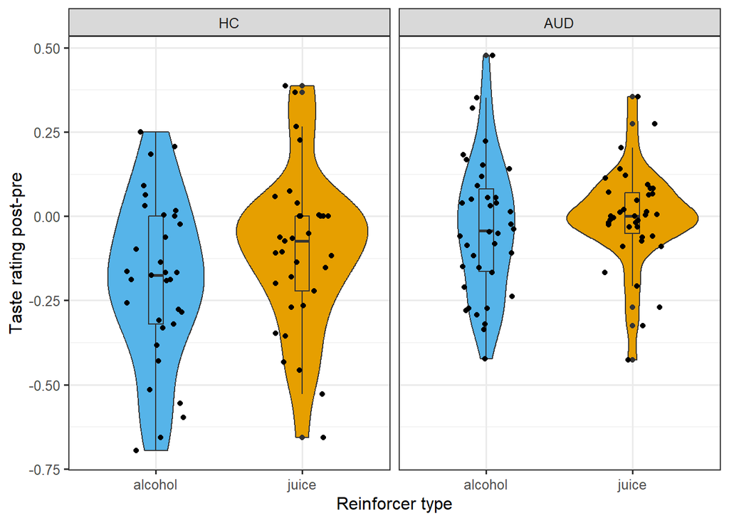

```r
fig1 <- ggplot(behav_rating, aes(reinforcer_type, y = taste_diff, fill=reinforcer_type)) +
  geom_violin() +
  geom_boxplot(width=0.1) +
  geom_jitter(shape=16, position=position_jitter(0.2)) +
  facet_wrap(~aud_group, scales="fixed") +
  scale_x_discrete("Reinforcer type", labels=c('alcohol', 'juice')) +
  scale_y_continuous("Taste rating post-pre") +
  scale_fill_manual("Reinforcer type", values = cbPalette[c(6,8)]) +
  theme_bw(base_size=12) +
  theme(legend.position = "none")

fig1
```

#### 4.3.1.2 Per group

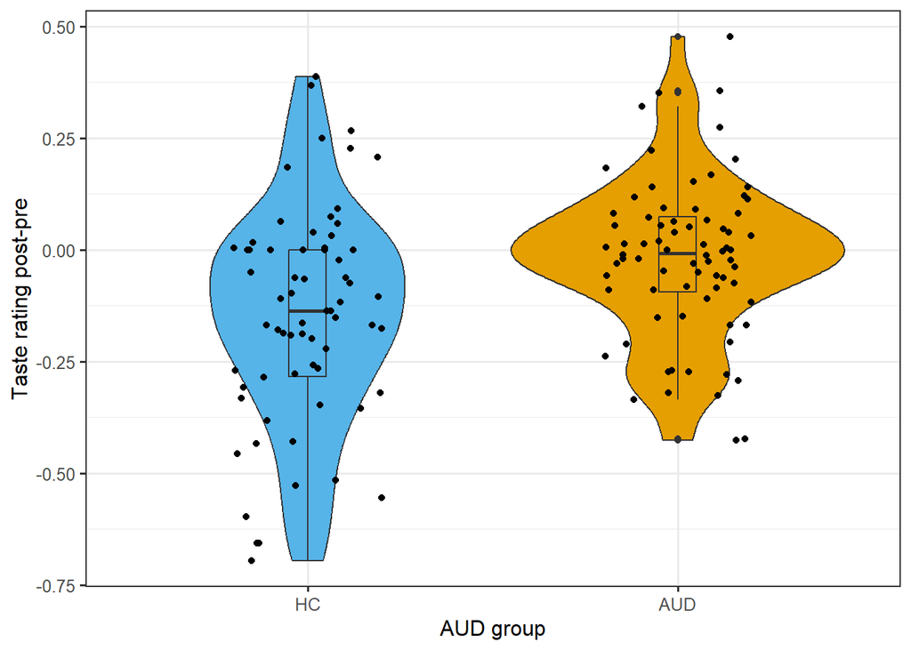

```r
fig1 <- ggplot(behav_rating, aes(aud_group, y = taste_diff, fill=aud_group)) +
  geom_violin() +
  geom_boxplot(width=0.1) +
  geom_jitter(shape=16, position=position_jitter(0.2)) +
  scale_x_discrete("AUD group", labels=c('HC', 'AUD')) +
  scale_y_continuous("Taste rating post-pre") +
  scale_fill_manual("AUD group", values = cbPalette[c(6,8)]) +
  theme_bw(base_size=12) +
  theme(legend.position = "none")

fig1
```

### 4.3.2 Craving difference

#### 4.3.2.1 Per group and reinforcer type

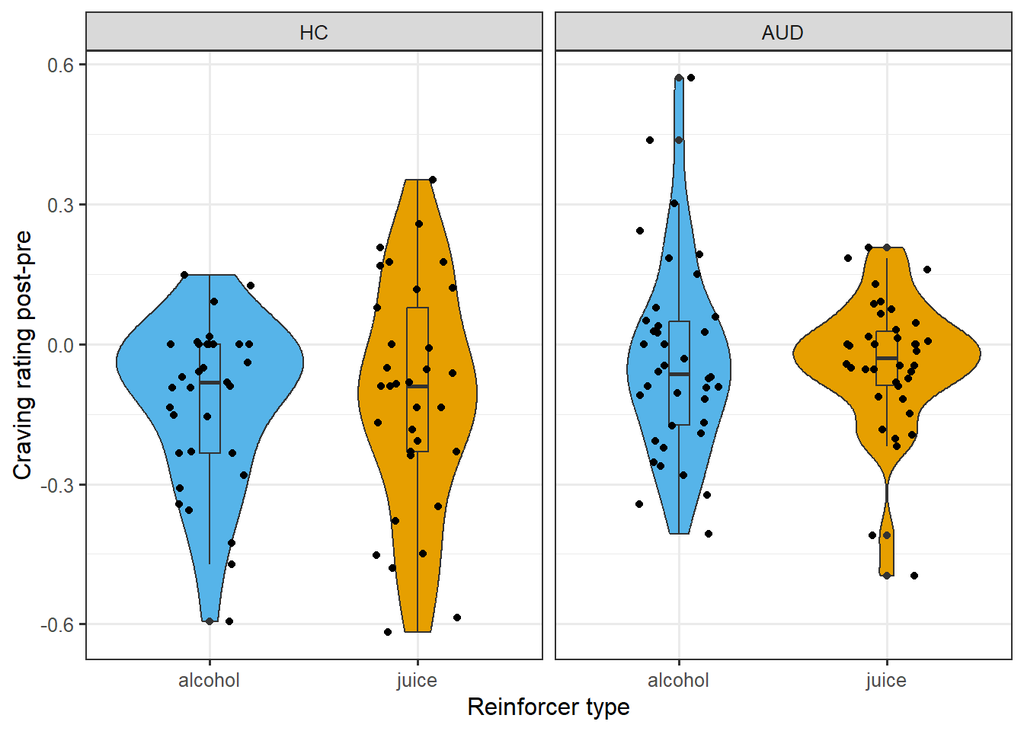

```r
fig1 <- ggplot(behav_rating, aes(reinforcer_type, y = crave_diff, fill=reinforcer_type)) +
  geom_violin() +
  geom_boxplot(width=0.1) +
  geom_jitter(shape=16, position=position_jitter(0.2)) +
  facet_wrap(~aud_group, scales="fixed") +
  scale_x_discrete("Reinforcer type", labels=c('alcohol', 'juice')) +
  scale_y_continuous("Craving rating post-pre") +
  scale_fill_manual("Reinforcer type", values = cbPalette[c(6,8)]) +
  theme_bw(base_size=12) +
  theme(legend.position = "none")

fig1
```

#### 4.3.2.2 Per group

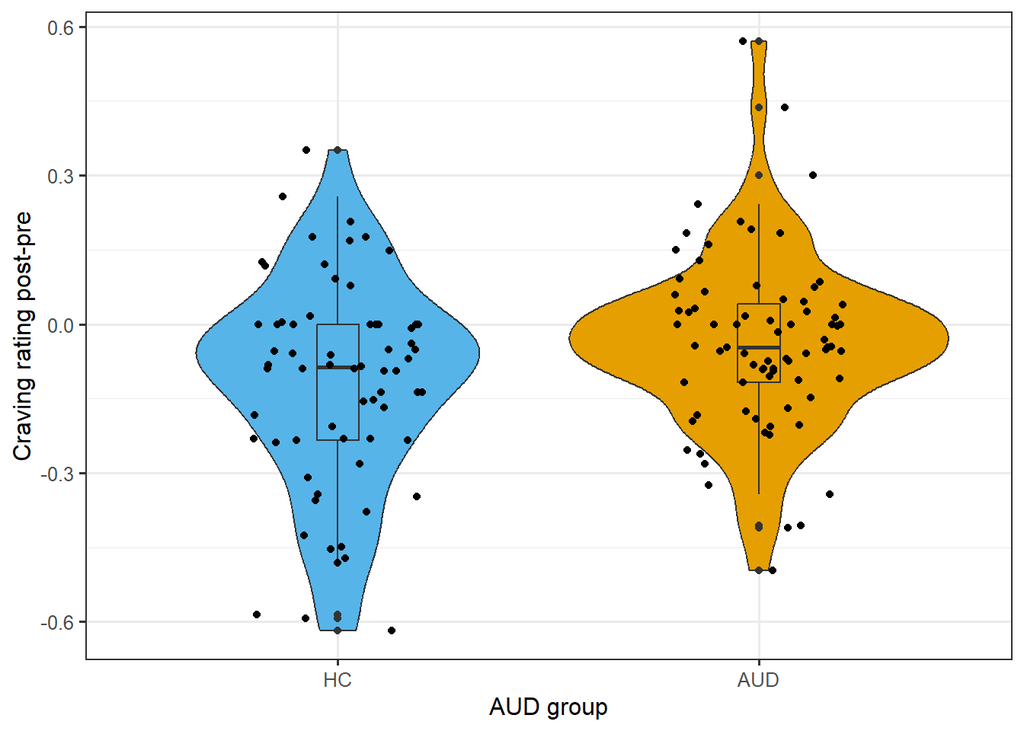

```r
fig1 <- ggplot(behav_rating, aes(aud_group, y = crave_diff, fill=aud_group)) +
  geom_violin() +
  geom_boxplot(width=0.1) +
  geom_jitter(shape=16, position=position_jitter(0.2)) +
  scale_x_discrete("AUD group", labels=c('HC', 'AUD')) +
  scale_y_continuous("Craving rating post-pre") +
  scale_fill_manual("AUD group", values = cbPalette[c(6,8)]) +
  theme_bw(base_size=12) +
  theme(legend.position = "none")

fig1
```

# 5 Correct choices

## 5.1 prepare dfs

```r
# get p correct per subject and block for linear mixed-effects regression
df_c <- behav_final %>%
  group_by(ID,reinforcer_type) %>%
  summarise_at(vars(correct), list(p_correct = mean), na.rm=T)
df_c <- merge(df_c,redcap,by="ID") # merge with demographic data for linear mixed-effects regression

# get p correct per block and trial for plotting
df_c_block_trial <- behav_final %>%
  group_by(reinforcer_type,trial_block) %>%
  summarise_at(vars(correct), list(p_correct = mean), na.rm=T)

# get p correct per block and aud group and trial for plotting
df_c_block_trial_group <- behav_final_redcap %>%
  group_by(aud_group,reinforcer_type,trial_block) %>%
  summarise_at(vars(correct), list(p_correct = mean), na.rm=T)
```

## 5.2 Descriptive stats

```r
# per group and reinforcer type
df_c_stats <- behav_final_redcap %>%
  group_by(reinforcer_type,aud_group) %>%
  dplyr::summarise(across(c('correct'), .fns=
                   list('_mean' = mean,
                        '_sd' = sd,
                        '_min' = min,
                        '_max' = max),
                   na.rm=T))
df_c_stats
```

```
# A tibble: 4 × 6
# Groups:   reinforcer_type [2]
  reinforcer_type aud_group correct__mean correct__sd correct__min correct__max
  <fct>           <fct>             <dbl>       <dbl>        <dbl>        <dbl>
1 A               HC                0.796       0.403            0            1
2 A               AUD               0.815       0.388            0            1
3 J               HC                0.825       0.380            0            1
4 J               AUD               0.849       0.358            0            1
```

```r
df_c_stats_nan <- behav_final_redcap %>%
  group_by(reinforcer_type,aud_group) %>%
  dplyr::summarise(across(c('correct'), .fns=
                   list('_na' = ~sum(is.na(.)))))
df_c_stats_nan
```

```
# A tibble: 4 × 3
# Groups:   reinforcer_type [2]
  reinforcer_type aud_group correct__na
  <fct>           <fct>           <int>
1 A               HC                 31
2 A               AUD                31
3 J               HC                 28
4 J               AUD                32
```

```r
# per group
df_c_stats <- behav_final_redcap %>%
  group_by(aud_group) %>%
  dplyr::summarise(across(c('correct'), .fns=
                   list('_mean' = mean,
                        '_sd' = sd,
                        '_min' = min,
                        '_max' = max),
                   na.rm=T))

df_c_stats
```

```
# A tibble: 2 × 5
  aud_group correct__mean correct__sd correct__min correct__max
  <fct>             <dbl>       <dbl>        <dbl>        <dbl>
1 HC                0.811       0.392            0            1
2 AUD               0.832       0.374            0            1
```

```r
df_c_stats_nan <- behav_final_redcap %>%
  group_by(aud_group) %>%
  dplyr::summarise(across(c('correct'), .fns=
                   list('_na' = ~sum(is.na(.)))))

df_c_stats_nan
```

```
# A tibble: 2 × 2
  aud_group correct__na
  <fct>           <int>
1 HC                 59
2 AUD                63
```

```r
# per reinforcer type
df_c_stats <- behav_final_redcap %>%
  group_by(reinforcer_type) %>%
  dplyr::summarise(across(c('correct'), .fns=
                   list('_mean' = mean,
                        '_sd' = sd,
                        '_min' = min,
                        '_max' = max),
                   na.rm=T))

df_c_stats
```

```
# A tibble: 2 × 5
  reinforcer_type correct__mean correct__sd correct__min correct__max
  <fct>                   <dbl>       <dbl>        <dbl>        <dbl>
1 A                       0.806       0.395            0            1
2 J                       0.838       0.369            0            1
```

```r
df_c_stats_nan <- behav_final_redcap %>%
  group_by(reinforcer_type) %>%
  dplyr::summarise(across(c('correct'), .fns=
                   list('_na' = ~sum(is.na(.)))))

df_c_stats_nan
```

```
# A tibble: 2 × 2
  reinforcer_type correct__na
  <fct>                 <int>
1 A                        62
2 J                        60
```

```r
# overall
df_c_stats <- behav_final_redcap %>%
  dplyr::summarise(across(c('correct'), .fns=
                   list('_mean' = mean,
                        '_sd' = sd,
                        '_min' = min,
                        '_max' = max),
                   na.rm=T))

df_c_stats
```

```
  correct__mean correct__sd correct__min correct__max
1     0.8221553   0.3824093            0            1
```

```r
df_c_stats_nan <- behav_final_redcap %>%
  dplyr::summarise(across(c('correct'), .fns=
                   list('_na' = ~sum(is.na(.)))))

df_c_stats_nan
```

```
  correct__na
1         122
```

```r
table(behav_final_redcap$correct)
```

```
   0    1
1241 5737
```

## 5.3 Linear mixed-effects regression

### 5.3.1 AUD group

```r
m_correct_1 <- lmer(p_correct ~ 1 + reinforcer_type*aud_group + (1 | ID), data=df_c, control=lmerControl(calc.derivs=FALSE), REML=F)
#m_correct_2 <- lmer(p_correct ~ 1 + reinforcer_type*aud_group + (1 + reinforcer_type || ID), data=df_c, control=lmerControl(calc.derivs=FALSE), REML=F)
#m_correct_3 <- lmer(p_correct ~ 1 + reinforcer_type*aud_group + (1 + reinforcer_type | ID), data=df_c, control=lmerControl(calc.derivs=FALSE), REML=F)

#anova(m_correct_1,m_correct_2,m_correct_3)

tab_model(m_correct_1,
          dv.labels=c("m_correct"), digits=3, digits.re=2,
          show.se=TRUE, show.stat=TRUE, show.df=TRUE, show.ci=FALSE,CSS = css_theme("cells"))
```

|  | m_correct |  |  |  |  |
| --- | --- | --- | --- | --- | --- |
| Predictors | Estimates | std. Error | Statistic | p | df |
| (Intercept) | 0.796 | 0.032 | 24.961 | **<0.001** | 136.000 |
| reinforcer type2 | 0.028 | 0.028 | 1.001 | 0.319 | 136.000 |
| aud group2 | 0.018 | 0.044 | 0.406 | 0.686 | 136.000 |
| reinforcer type2 × aud group2 | 0.007 | 0.038 | 0.183 | 0.855 | 136.000 |
| Random Effects |  |  |  |  |  |
| σ<sup>2</sup> | 0.01 |  |  |  |  |
| τ<sub>00</sub> <sub>ID</sub> | 0.02 |  |  |  |  |
| ICC | 0.62 |  |  |  |  |
| N <sub>ID</sub> | 71 |  |  |  |  |
| Observations | 142 |  |  |  |  |
| Marginal R<sup>2</sup> / Conditional R<sup>2</sup> | 0.011 / 0.625 |  |  |  |  |

We cannot include reinforcer type as random effect as the model would be unidentifiable.

We find - n.s. effects.

### 5.3.2 AUD criteria

```r
m_correct_1_audsum <- lmer(p_correct ~ 1 + reinforcer_type*aud_sum + (1 | ID), data=df_c, control=lmerControl(calc.derivs=FALSE), REML=F)
#m_correct_2_audsum <- lmer(p_correct ~ 1 + reinforcer_type*aud_sum + (1 + reinforcer_type || ID), data=df_c, control=lmerControl(calc.derivs=FALSE), REML=F)
#m_correct_3_audsum <- lmer(p_correct ~ 1 + reinforcer_type*aud_sum + (1 + reinforcer_type | ID), data=df_c, control=lmerControl(calc.derivs=FALSE), REML=F)

#anova(m_correct_1_audsum,m_correct_2_audsum,m_correct_3_audsum)

tab_model(m_correct_1_audsum,
          dv.labels=c("m_correct"), digits=3, digits.re=2,
          show.se=TRUE, show.stat=TRUE, show.df=TRUE, show.ci=FALSE,CSS = css_theme("cells"))
```

|  | m_correct |  |  |  |  |
| --- | --- | --- | --- | --- | --- |
| Predictors | Estimates | std. Error | Statistic | p | df |
| (Intercept) | 0.793 | 0.031 | 25.665 | **<0.001** | 136.000 |
| reinforcer type2 | 0.047 | 0.027 | 1.756 | 0.081 | 136.000 |
| aud sum | 0.005 | 0.009 | 0.583 | 0.561 | 136.000 |
| reinforcer type2 × aud sum | -0.007 | 0.008 | -0.815 | 0.416 | 136.000 |
| Random Effects |  |  |  |  |  |
| σ<sup>2</sup> | 0.01 |  |  |  |  |
| τ<sub>00</sub> <sub>ID</sub> | 0.02 |  |  |  |  |
| ICC | 0.62 |  |  |  |  |
| N <sub>ID</sub> | 71 |  |  |  |  |
| Observations | 142 |  |  |  |  |
| Marginal R<sup>2</sup> / Conditional R<sup>2</sup> | 0.010 / 0.628 |  |  |  |  |

We cannot include reinforcer type as random effect as the model would be unidentifiable.

We find - n.s. effects.

### 5.3.3 AUDIT criteria

```r
m_correct_1_auditsum <- lmer(p_correct ~ 1 + reinforcer_type*audit_sum + (1 | ID), data=df_c, control=lmerControl(calc.derivs=FALSE), REML=F)
#m_correct_2_auditsum <- lmer(p_correct ~ 1 + reinforcer_type*audit_sum + (1 + reinforcer_type || ID), data=df_c, control=lmerControl(calc.derivs=FALSE), REML=F)
#m_correct_3_auditsum <- lmer(p_correct ~ 1 + reinforcer_type*audit_sum + (1 + reinforcer_type | ID), data=df_c, control=lmerControl(calc.derivs=FALSE), REML=F)

#anova(m_correct_1_auditsum,m_correct_2_auditsum,m_correct_3_auditsum)

tab_model(m_correct_1_auditsum,
          dv.labels=c("m_correct"), digits=3, digits.re=2,
          show.se=TRUE, show.stat=TRUE, show.df=TRUE, show.ci=FALSE,CSS = css_theme("cells"))
```

|  | m_correct |  |  |  |  |
| --- | --- | --- | --- | --- | --- |
| Predictors | Estimates | std. Error | Statistic | p | df |
| (Intercept) | 0.775 | 0.038 | 20.668 | **<0.001** | 136.000 |
| reinforcer type2 | 0.063 | 0.032 | 1.941 | 0.054 | 136.000 |
| audit sum | 0.003 | 0.003 | 0.998 | 0.320 | 136.000 |
| reinforcer type2 × audit sum | -0.003 | 0.003 | -1.187 | 0.237 | 136.000 |
| Random Effects |  |  |  |  |  |
| σ<sup>2</sup> | 0.01 |  |  |  |  |
| τ<sub>00</sub> <sub>ID</sub> | 0.02 |  |  |  |  |
| ICC | 0.63 |  |  |  |  |
| N <sub>ID</sub> | 71 |  |  |  |  |
| Observations | 142 |  |  |  |  |
| Marginal R<sup>2</sup> / Conditional R<sup>2</sup> | 0.014 / 0.632 |  |  |  |  |

We cannot include reinforcer type as random effect as the model would be unidentifiable.

We find - n.s. effects.

## 5.4 Exploratory: Logistic mixed-effects regression

### 5.4.1 AUD group

```r
m_correct_log_1 <- glmer(correct ~ 1 + reinforcer_type*aud_group + (1 | ID), data=behav_final_redcap, family = binomial, control=glmerControl(calc.derivs=FALSE))
m_correct_log_2 <- glmer(correct ~ 1 + reinforcer_type*aud_group + (1 + reinforcer_type || ID), data=behav_final_redcap, family = binomial, control=glmerControl(calc.derivs=FALSE))
m_correct_log_3 <- glmer(correct ~ 1 + reinforcer_type*aud_group + (1 + reinforcer_type | ID), data=behav_final_redcap, family = binomial, control=glmerControl(calc.derivs=FALSE))

anova(m_correct_log_1,m_correct_log_2)
```

```
Data: behav_final_redcap
Models:
m_correct_log_1: correct ~ 1 + reinforcer_type * aud_group + (1 | ID)
m_correct_log_2: correct ~ 1 + reinforcer_type * aud_group + (1 + reinforcer_type || ID)
                npar    AIC    BIC  logLik deviance  Chisq Df Pr(>Chisq)
m_correct_log_1    5 5474.1 5508.4 -2732.1   5464.1
m_correct_log_2    8 5326.6 5381.4 -2655.3   5310.6 153.57  3  < 2.2e-16 ***
---
Signif. codes:  0 '***' 0.001 '**' 0.01 '*' 0.05 '.' 0.1 ' ' 1
```

```r
anova(m_correct_log_2,m_correct_log_3)
```

```
Data: behav_final_redcap
Models:
m_correct_log_3: correct ~ 1 + reinforcer_type * aud_group + (1 + reinforcer_type | ID)
m_correct_log_2: correct ~ 1 + reinforcer_type * aud_group + (1 + reinforcer_type || ID)
                npar    AIC    BIC  logLik deviance Chisq Df Pr(>Chisq)
m_correct_log_3    7 5324.6 5372.5 -2655.3   5310.6
m_correct_log_2    8 5326.6 5381.4 -2655.3   5310.6 1e-04  1     0.9927
```

```r
tab_model(m_correct_log_2,
          dv.labels=c("m_correct_log"), digits=3, digits.re=2,
          show.se=TRUE, show.stat=TRUE, show.df=TRUE, show.ci=FALSE,CSS = css_theme("cells"))
```

|  | m_correct_log |  |  |  |  |
| --- | --- | --- | --- | --- | --- |
| Predictors | Odds Ratios | std. Error | Statistic | p | df |
| (Intercept) | 6.440 | 1.790 | 6.702 | **<0.001** | Inf |
| reinforcer type2 | 1.491 | 0.407 | 1.461 | 0.144 | Inf |
| aud group2 | 1.355 | 0.519 | 0.794 | 0.427 | Inf |
| reinforcer type2 × aud group2 | 1.080 | 0.411 | 0.203 | 0.839 | Inf |
| Random Effects |  |  |  |  |  |
| σ<sup>2</sup> | 3.29 |  |  |  |  |
| τ<sub>00</sub> <sub>ID</sub> | 1.66 |  |  |  |  |
| τ<sub>11</sub> <sub>ID.reinforcer_typeA</sub> | 0.63 |  |  |  |  |
| τ<sub>11</sub> <sub>ID.reinforcer_typeJ</sub> | 1.35 |  |  |  |  |
| ρ<sub>01</sub> |  |  |  |  |  |
| ρ<sub>01</sub> |  |  |  |  |  |
| ICC | 0.33 |  |  |  |  |
| N <sub>ID</sub> | 71 |  |  |  |  |
| Observations | 6978 |  |  |  |  |
| Marginal R<sup>2</sup> / Conditional R<sup>2</sup> | 0.016 / 0.345 |  |  |  |  |

### 5.4.2 AUD criteria

```r
m_correct_log_1_audsum <- glmer(correct ~ 1 + reinforcer_type*aud_sum + (1 | ID), data=behav_final_redcap, family = binomial, control=glmerControl(calc.derivs=FALSE))
m_correct_log_2_audsum <- glmer(correct ~ 1 + reinforcer_type*aud_sum + (1 + reinforcer_type || ID), data=behav_final_redcap, family = binomial, control=glmerControl(calc.derivs=FALSE))
m_correct_log_3_audsum <- glmer(correct ~ 1 + reinforcer_type*aud_sum + (1 + reinforcer_type | ID), data=behav_final_redcap, family = binomial, control=glmerControl(calc.derivs=FALSE))

anova(m_correct_log_1_audsum,m_correct_log_2_audsum)
```

```
Data: behav_final_redcap
Models:
m_correct_log_1_audsum: correct ~ 1 + reinforcer_type * aud_sum + (1 | ID)
m_correct_log_2_audsum: correct ~ 1 + reinforcer_type * aud_sum + (1 + reinforcer_type || ID)
                       npar    AIC    BIC  logLik deviance  Chisq Df Pr(>Chisq)
m_correct_log_1_audsum    5 5471.7 5505.9 -2730.8   5461.7
m_correct_log_2_audsum    8 5326.8 5381.7 -2655.4   5310.8 150.85  3  < 2.2e-16

m_correct_log_1_audsum
m_correct_log_2_audsum ***
---
Signif. codes:  0 '***' 0.001 '**' 0.01 '*' 0.05 '.' 0.1 ' ' 1
```

```r
anova(m_correct_log_2_audsum,m_correct_log_3_audsum)
```

```
Data: behav_final_redcap
Models:
m_correct_log_3_audsum: correct ~ 1 + reinforcer_type * aud_sum + (1 + reinforcer_type | ID)
m_correct_log_2_audsum: correct ~ 1 + reinforcer_type * aud_sum + (1 + reinforcer_type || ID)
                       npar    AIC    BIC  logLik deviance Chisq Df Pr(>Chisq)
m_correct_log_3_audsum    7 5324.8 5372.8 -2655.4   5310.8
m_correct_log_2_audsum    8 5326.8 5381.7 -2655.4   5310.8 1e-04  1     0.9934
```

```r
tab_model(m_correct_log_2_audsum,
          dv.labels=c("m_correct_log"), digits=3, digits.re=2,
          show.se=TRUE, show.stat=TRUE, show.df=TRUE, show.ci=FALSE,CSS = css_theme("cells"))
```

|  | m_correct_log |  |  |  |  |
| --- | --- | --- | --- | --- | --- |
| Predictors | Odds Ratios | std. Error | Statistic | p | df |
| (Intercept) | 6.543 | 1.766 | 6.958 | **<0.001** | Inf |
| reinforcer type2 | 1.682 | 0.450 | 1.943 | 0.052 | Inf |
| aud sum | 1.064 | 0.088 | 0.755 | 0.450 | Inf |
| reinforcer type2 × aud sum | 0.967 | 0.080 | -0.412 | 0.680 | Inf |
| Random Effects |  |  |  |  |  |
| σ<sup>2</sup> | 3.29 |  |  |  |  |
| τ<sub>00</sub> <sub>ID</sub> | 1.64 |  |  |  |  |
| τ<sub>11</sub> <sub>ID.reinforcer_typeA</sub> | 0.65 |  |  |  |  |
| τ<sub>11</sub> <sub>ID.reinforcer_typeJ</sub> | 1.38 |  |  |  |  |
| ρ<sub>01</sub> |  |  |  |  |  |
| ρ<sub>01</sub> |  |  |  |  |  |
| ICC | 0.33 |  |  |  |  |
| N <sub>ID</sub> | 71 |  |  |  |  |
| Observations | 6978 |  |  |  |  |
| Marginal R<sup>2</sup> / Conditional R<sup>2</sup> | 0.012 / 0.341 |  |  |  |  |

We find - n.s. effects.

### 5.4.3 AUDIT criteria

```r
m_correct_log_1_auditsum <- glmer(correct ~ 1 + reinforcer_type*audit_sum + (1 | ID), data=behav_final_redcap, family = binomial, control=glmerControl(calc.derivs=FALSE))
m_correct_log_2_auditsum <- glmer(correct ~ 1 + reinforcer_type*audit_sum + (1 + reinforcer_type || ID), data=behav_final_redcap, family = binomial, control=glmerControl(calc.derivs=FALSE))
m_correct_log_3_auditsum <- glmer(correct ~ 1 + reinforcer_type*audit_sum + (1 + reinforcer_type | ID), data=behav_final_redcap, family = binomial, control=glmerControl(calc.derivs=FALSE))

anova(m_correct_log_1_auditsum,m_correct_log_2_auditsum)
```

```
Data: behav_final_redcap
Models:
m_correct_log_1_auditsum: correct ~ 1 + reinforcer_type * audit_sum + (1 | ID)
m_correct_log_2_auditsum: correct ~ 1 + reinforcer_type * audit_sum + (1 + reinforcer_type || ID)
                         npar    AIC    BIC  logLik deviance  Chisq Df
m_correct_log_1_auditsum    5 5467.8 5502.1 -2728.9   5457.8
m_correct_log_2_auditsum    8 5326.3 5381.1 -2655.1   5310.3 147.54  3
                         Pr(>Chisq)
m_correct_log_1_auditsum
m_correct_log_2_auditsum  < 2.2e-16 ***
---
Signif. codes:  0 '***' 0.001 '**' 0.01 '*' 0.05 '.' 0.1 ' ' 1
```

```r
anova(m_correct_log_2_auditsum,m_correct_log_3_auditsum)
```

```
Data: behav_final_redcap
Models:
m_correct_log_3_auditsum: correct ~ 1 + reinforcer_type * audit_sum + (1 + reinforcer_type | ID)
m_correct_log_2_auditsum: correct ~ 1 + reinforcer_type * audit_sum + (1 + reinforcer_type || ID)
                         npar    AIC    BIC  logLik deviance Chisq Df
m_correct_log_3_auditsum    7 5324.3 5372.2 -2655.1   5310.3
m_correct_log_2_auditsum    8 5326.3 5381.1 -2655.1   5310.3 1e-04  1
                         Pr(>Chisq)
m_correct_log_3_auditsum
m_correct_log_2_auditsum     0.9939
```

```r
tab_model(m_correct_log_2_auditsum,
          dv.labels=c("m_correct_log"), digits=3, digits.re=2,
          show.se=TRUE, show.stat=TRUE, show.df=TRUE, show.ci=FALSE,CSS = css_theme("cells"))
```

|  | m_correct_log |  |  |  |  |
| --- | --- | --- | --- | --- | --- |
| Predictors | Odds Ratios | std. Error | Statistic | p | df |
| (Intercept) | 5.687 | 1.860 | 5.314 | **<0.001** | Inf |
| reinforcer type2 | 1.820 | 0.592 | 1.843 | 0.065 | Inf |
| audit sum | 1.032 | 0.031 | 1.058 | 0.290 | Inf |
| reinforcer type2 × audit sum | 0.983 | 0.029 | -0.584 | 0.559 | Inf |
| Random Effects |  |  |  |  |  |
| σ<sup>2</sup> | 3.29 |  |  |  |  |
| τ<sub>00</sub> <sub>ID</sub> | 1.68 |  |  |  |  |
| τ<sub>11</sub> <sub>ID.reinforcer_typeA</sub> | 0.58 |  |  |  |  |
| τ<sub>11</sub> <sub>ID.reinforcer_typeJ</sub> | 1.34 |  |  |  |  |
| ρ<sub>01</sub> |  |  |  |  |  |
| ρ<sub>01</sub> |  |  |  |  |  |
| ICC | 0.34 |  |  |  |  |
| N <sub>ID</sub> | 71 |  |  |  |  |
| Observations | 6978 |  |  |  |  |
| Marginal R<sup>2</sup> / Conditional R<sup>2</sup> | 0.015 / 0.348 |  |  |  |  |

## 5.5 Plotting

### 5.5.1 Per group and reinforcer type

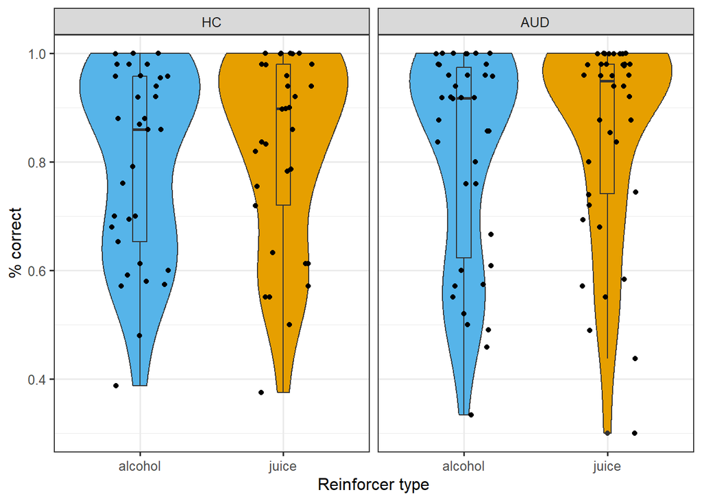

```r
fig1 <- ggplot(df_c, aes(reinforcer_type, y = p_correct, fill=reinforcer_type)) +
  geom_violin() +
  geom_boxplot(width=0.1) +
  geom_jitter(shape=16, position=position_jitter(0.2)) +
  facet_wrap(~aud_group, scales="fixed") +
  scale_x_discrete("Reinforcer type", labels=c('alcohol', 'juice')) +
  scale_y_continuous("% correct") +
  scale_fill_manual("Reinforcer type", values = cbPalette[c(6,8)]) +
  theme_bw(base_size=12) +
  theme(legend.position = "none")

fig1
```

### 5.5.2 Correct choices over course of task

#### 5.5.2.1 Per block

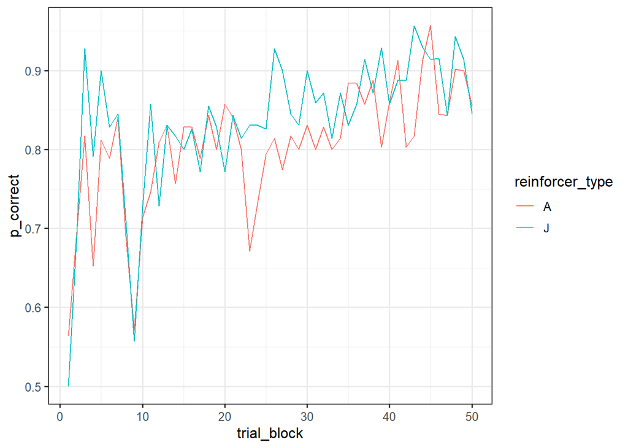

```r
fig2 <- ggplot(df_c_block_trial, aes(x=trial_block, y=p_correct, group=reinforcer_type)) +
  geom_line(aes(color=reinforcer_type)) +
  scale_fill_manual("Reinforcer type", values = cbPalette[c(1,2)]) +
  theme_bw(base_size=12)

fig2
```

- P correct per block and trial across subjects.
- Drops most likely due to probabilistic events - same across all subjects, different across versions, but partially overlapping (e.g. 7,8 in version A, 7,8,9 in version B).
- p_correct quickly rises above 0.5 –> subjects chose rewarded card more often –> rewards aren’t generally aversive
- p_correct is generally higher for juice vs. alcohol reward
- no string ceiling effect, but p_correct rises quickly

#### 5.5.2.2 Per block and aud group

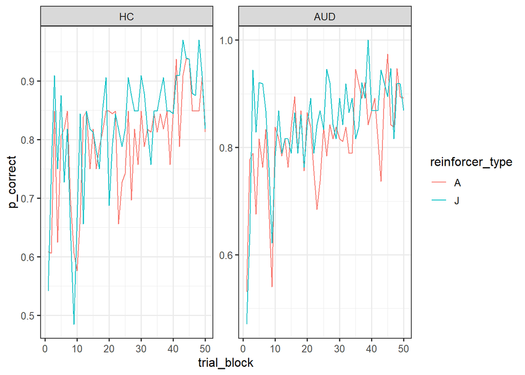

```r
fig3 <- ggplot(df_c_block_trial_group, aes(x=trial_block, y=p_correct, group=reinforcer_type)) +
  geom_line(aes(color=reinforcer_type)) +
  scale_fill_manual("Reinforcer type", values = cbPalette[c(1,2)]) +
  theme_bw(base_size=12) +
  facet_wrap(~aud_group, scales="free_y")

fig3
```

# 6 Win-Stay behavior: Repeating the same action that was rewarded in previous trial

## 6.1 Prepare dfs

```r
# get p correct per subject and block for linear mixed-effects regression
df_win_stay <- behav_final %>%
  group_by(ID,reinforcer_type,na.rm=T) %>%
  summarise_at(vars(stay,win_stay), list(p = mean), na.rm=T) %>%
  na.omit()
df_win_stay <- merge(df_win_stay,redcap,by="ID") # merge with demographic data for linear mixed-effects

# get p correct per block and trial for plotting
df_win_stay_trial <- behav_final %>%
  group_by(reinforcer_type,trial_block) %>%
  summarise_at(vars(win_stay), list(p = mean), na.rm=T)

# get p correct per block and aud group and trial for plotting
df_win_stay_trial_group <- behav_final_redcap %>%
  group_by(aud_group,reinforcer_type,trial_block) %>%
  summarise_at(vars(win_stay), list(p = mean), na.rm=T)
```

## 6.2 Linear mixed-effects regression win_stay

### 6.2.1 AUD group

```r
m_win_stay_1=lmer(win_stay_p~reinforcer_type*aud_group + (1 | ID),
                data=df_win_stay,
                control=lmerControl(calc.derivs=FALSE))
#m_win_stay_2=lmer(win_stay_p~reinforcer_type*aud_group + (1 + reinforcer_type || ID),
#                data=df_win_stay,
#                control=lmerControl(calc.derivs=FALSE))
#m_win_stay_3=lmer(win_stay_p~reinforcer_type*aud_group + (1 + reinforcer_type | ID),
#                data=df_win_stay,
#                control=lmerControl(calc.derivs=FALSE))
#anova(m_win_stay_1,m_win_stay_2,m_win_stay_3)

tab_model(m_win_stay_1,
          dv.labels=c("m_stay"), digits=3, digits.re=2,
          show.se=TRUE, show.stat=TRUE, show.df=TRUE, show.ci=FALSE,CSS = css_theme("cells"))
```

|  | m_stay |  |  |  |  |
| --- | --- | --- | --- | --- | --- |
| Predictors | Estimates | std. Error | Statistic | p | df |
| (Intercept) | 0.513 | 0.026 | 19.508 | **<0.001** | 136.000 |
| reinforcer type2 | 0.033 | 0.022 | 1.519 | 0.131 | 136.000 |
| aud group2 | 0.019 | 0.036 | 0.538 | 0.592 | 136.000 |
| reinforcer type2 × aud group2 | -0.001 | 0.030 | -0.022 | 0.983 | 136.000 |
| Random Effects |  |  |  |  |  |
| σ<sup>2</sup> | 0.01 |  |  |  |  |
| τ<sub>00</sub> <sub>ID</sub> | 0.01 |  |  |  |  |
| ICC | 0.65 |  |  |  |  |
| N <sub>ID</sub> | 71 |  |  |  |  |
| Observations | 142 |  |  |  |  |
| Marginal R<sup>2</sup> / Conditional R<sup>2</sup> | 0.016 / 0.657 |  |  |  |  |

### 6.2.2 AUD criteria

```r
m_win_stay_1_audsum=lmer(win_stay_p~reinforcer_type*aud_sum + (1 | ID),
                data=df_win_stay,
                control=lmerControl(calc.derivs=FALSE))
#m_win_stay_2_audsum=lmer(win_stay_p~reinforcer_type*aud_sum + (1 + reinforcer_type || ID),
#                data=df_win_stay,
#                control=lmerControl(calc.derivs=FALSE))
#m_win_stay_3_audsum=lmer(win_stay_p~reinforcer_type*aud_sum + (1 + reinforcer_type | ID),
#                data=df_win_stay,
#                control=lmerControl(calc.derivs=FALSE))
#anova(m_win_stay_1_audsum,m_win_stay_2_audsum,m_win_stay_3_audsum)

tab_model(m_win_stay_1_audsum,
          dv.labels=c("m_stay"), digits=3, digits.re=2,
          show.se=TRUE, show.stat=TRUE, show.df=TRUE, show.ci=FALSE,CSS = css_theme("cells"))
```

|  | m_stay |  |  |  |  |
| --- | --- | --- | --- | --- | --- |
| Predictors | Estimates | std. Error | Statistic | p | df |
| (Intercept) | 0.519 | 0.026 | 20.330 | **<0.001** | 136.000 |
| reinforcer type2 | 0.037 | 0.021 | 1.749 | 0.083 | 136.000 |
| aud sum | 0.002 | 0.008 | 0.270 | 0.787 | 136.000 |
| reinforcer type2 × aud sum | -0.002 | 0.006 | -0.275 | 0.784 | 136.000 |
| Random Effects |  |  |  |  |  |
| σ<sup>2</sup> | 0.01 |  |  |  |  |
| τ<sub>00</sub> <sub>ID</sub> | 0.01 |  |  |  |  |
| ICC | 0.65 |  |  |  |  |
| N <sub>ID</sub> | 71 |  |  |  |  |
| Observations | 142 |  |  |  |  |
| Marginal R<sup>2</sup> / Conditional R<sup>2</sup> | 0.012 / 0.658 |  |  |  |  |

### 6.2.3 AUDIT criteria

```r
m_win_stay_1_auditsum=lmer(win_stay_p~reinforcer_type*audit_sum + (1 | ID),
                data=df_win_stay,
                control=lmerControl(calc.derivs=FALSE))
#m_win_stay_2_auditsum=lmer(win_stay_p~reinforcer_type*audit_sum + (1 + reinforcer_type || ID),
#                data=df_win_stay,
#                control=lmerControl(calc.derivs=FALSE))
#m_win_stay_3_auditsum=lmer(win_stay_p~reinforcer_type*audit_sum + (1 + reinforcer_type | ID),
#                data=df_win_stay,
#                control=lmerControl(calc.derivs=FALSE))
#anova(m_win_stay_1_auditsum,m_win_stay_2_auditsum,m_win_stay_3_auditsum)

tab_model(m_win_stay_1_auditsum,
          dv.labels=c("m_stay"), digits=3, digits.re=2,
          show.se=TRUE, show.stat=TRUE, show.df=TRUE, show.ci=FALSE,CSS = css_theme("cells"))
```

|  | m_stay |  |  |  |  |
| --- | --- | --- | --- | --- | --- |
| Predictors | Estimates | std. Error | Statistic | p | df |
| (Intercept) | 0.497 | 0.031 | 16.066 | **<0.001** | 136.000 |
| reinforcer type2 | 0.050 | 0.026 | 1.952 | 0.053 | 136.000 |
| audit sum | 0.003 | 0.003 | 1.072 | 0.286 | 136.000 |
| reinforcer type2 × audit sum | -0.002 | 0.002 | -0.822 | 0.413 | 136.000 |
| Random Effects |  |  |  |  |  |
| σ<sup>2</sup> | 0.01 |  |  |  |  |
| τ<sub>00</sub> <sub>ID</sub> | 0.01 |  |  |  |  |
| ICC | 0.65 |  |  |  |  |
| N <sub>ID</sub> | 71 |  |  |  |  |
| Observations | 142 |  |  |  |  |
| Marginal R<sup>2</sup> / Conditional R<sup>2</sup> | 0.021 / 0.661 |  |  |  |  |

### 6.3.1 AUD group

```r
m_win_stay_log_1=lmer(win_stay~reinforcer_type*aud_group + (1 | ID),
                data=behav_final_redcap,
                control=lmerControl(calc.derivs=FALSE))
m_win_stay_log_2=lmer(win_stay~reinforcer_type*aud_group + (1 + reinforcer_type || ID),
                data=behav_final_redcap,
                control=lmerControl(calc.derivs=FALSE))
m_win_stay_log_3=lmer(win_stay~reinforcer_type*aud_group + (1 + reinforcer_type | ID),
                data=behav_final_redcap,
                control=lmerControl(calc.derivs=FALSE))

anova(m_win_stay_log_1,m_win_stay_log_2)
```

```
refitting model(s) with ML (instead of REML)
```

```
Data: behav_final_redcap
Models:
m_win_stay_log_1: win_stay ~ reinforcer_type * aud_group + (1 | ID)
m_win_stay_log_2: win_stay ~ reinforcer_type * aud_group + (1 + reinforcer_type || ID)
                 npar    AIC    BIC  logLik deviance Chisq Df Pr(>Chisq)
m_win_stay_log_1    6 9504.8 9545.8 -4746.4   9492.8
m_win_stay_log_2    9 9502.5 9563.9 -4742.3   9484.5 8.304  3    0.04013 *
---
Signif. codes:  0 '***' 0.001 '**' 0.01 '*' 0.05 '.' 0.1 ' ' 1
```

```r
anova(m_win_stay_log_2,m_win_stay_log_3)
```

```
refitting model(s) with ML (instead of REML)
```

```
Data: behav_final_redcap
Models:
m_win_stay_log_3: win_stay ~ reinforcer_type * aud_group + (1 + reinforcer_type | ID)
m_win_stay_log_2: win_stay ~ reinforcer_type * aud_group + (1 + reinforcer_type || ID)
                 npar    AIC    BIC  logLik deviance Chisq Df Pr(>Chisq)
m_win_stay_log_3    8 9500.5 9555.1 -4742.3   9484.5
m_win_stay_log_2    9 9502.5 9563.9 -4742.3   9484.5     0  1          1
```

```r
anova(m_win_stay_log_1,m_win_stay_log_3)
```

```
refitting model(s) with ML (instead of REML)
```

```
Data: behav_final_redcap
Models:
m_win_stay_log_1: win_stay ~ reinforcer_type * aud_group + (1 | ID)
m_win_stay_log_3: win_stay ~ reinforcer_type * aud_group + (1 + reinforcer_type | ID)
                 npar    AIC    BIC  logLik deviance Chisq Df Pr(>Chisq)
m_win_stay_log_1    6 9504.8 9545.8 -4746.4   9492.8
m_win_stay_log_3    8 9500.5 9555.1 -4742.3   9484.5 8.304  2    0.01573 *
---
Signif. codes:  0 '***' 0.001 '**' 0.01 '*' 0.05 '.' 0.1 ' ' 1
```

```r
tab_model(m_win_stay_log_3,
          dv.labels=c("m_stay"), digits=3, digits.re=2,
          show.se=TRUE, show.stat=TRUE, show.df=TRUE, show.ci=FALSE,CSS = css_theme("cells"))
```

|  | m_stay |  |  |  |  |
| --- | --- | --- | --- | --- | --- |
| Predictors | Estimates | std. Error | Statistic | p | df |
| (Intercept) | 0.513 | 0.027 | 19.302 | **<0.001** | 6782.000 |
| reinforcer type2 | 0.034 | 0.022 | 1.541 | 0.123 | 6782.000 |
| aud group2 | 0.020 | 0.036 | 0.547 | 0.584 | 6782.000 |
| reinforcer type2 × aud group2 | -0.002 | 0.030 | -0.051 | 0.959 | 6782.000 |
| Random Effects |  |  |  |  |  |
| σ<sup>2</sup> | 0.23 |  |  |  |  |
| τ<sub>00</sub> <sub>ID</sub> | 0.02 |  |  |  |  |
| τ<sub>11</sub> <sub>ID.reinforcer_type2</sub> | 0.01 |  |  |  |  |
| ρ<sub>01</sub> <sub>ID</sub> | -0.33 |  |  |  |  |
| ICC | 0.07 |  |  |  |  |
| N <sub>ID</sub> | 71 |  |  |  |  |
| Observations | 6790 |  |  |  |  |
| Marginal R<sup>2</sup> / Conditional R<sup>2</sup> | 0.001 / 0.074 |  |  |  |  |

Model 2 fails to converge. Model 3 is better than model 1.

### 6.3.2 AUD criteria

```r
m_win_stay_log_1_audsum=lmer(win_stay~reinforcer_type*aud_sum + (1 | ID),
                data=behav_final_redcap,
                control=lmerControl(calc.derivs=FALSE))
m_win_stay_log_2_audsum=lmer(win_stay~reinforcer_type*aud_sum + (1 + reinforcer_type || ID),
                data=behav_final_redcap,
                control=lmerControl(calc.derivs=FALSE))
m_win_stay_log_3_audsum=lmer(win_stay~reinforcer_type*aud_sum + (1 + reinforcer_type | ID),
                data=behav_final_redcap,
                control=lmerControl(calc.derivs=FALSE))

anova(m_win_stay_log_1_audsum,m_win_stay_log_2_audsum)
```

```
refitting model(s) with ML (instead of REML)
```

```
Data: behav_final_redcap
Models:
m_win_stay_log_1_audsum: win_stay ~ reinforcer_type * aud_sum + (1 | ID)
m_win_stay_log_2_audsum: win_stay ~ reinforcer_type * aud_sum + (1 + reinforcer_type || ID)
                        npar    AIC    BIC  logLik deviance  Chisq Df
m_win_stay_log_1_audsum    6 9505.0 9545.9 -4746.5   9493.0
m_win_stay_log_2_audsum    9 9502.7 9564.2 -4742.4   9484.7 8.2515  3
                        Pr(>Chisq)
m_win_stay_log_1_audsum
m_win_stay_log_2_audsum    0.04109 *
---
Signif. codes:  0 '***' 0.001 '**' 0.01 '*' 0.05 '.' 0.1 ' ' 1
```

```r
anova(m_win_stay_log_2_audsum,m_win_stay_log_3_audsum)
```

```
refitting model(s) with ML (instead of REML)
```

```
Data: behav_final_redcap
Models:
m_win_stay_log_3_audsum: win_stay ~ reinforcer_type * aud_sum + (1 + reinforcer_type | ID)
m_win_stay_log_2_audsum: win_stay ~ reinforcer_type * aud_sum + (1 + reinforcer_type || ID)
                        npar    AIC    BIC  logLik deviance Chisq Df Pr(>Chisq)
m_win_stay_log_3_audsum    8 9500.7 9555.3 -4742.4   9484.7
m_win_stay_log_2_audsum    9 9502.7 9564.2 -4742.4   9484.7     0  1          1
```

```r
anova(m_win_stay_log_1_audsum,m_win_stay_log_3_audsum)
```

```
refitting model(s) with ML (instead of REML)
```

```
Data: behav_final_redcap
Models:
m_win_stay_log_1_audsum: win_stay ~ reinforcer_type * aud_sum + (1 | ID)
m_win_stay_log_3_audsum: win_stay ~ reinforcer_type * aud_sum + (1 + reinforcer_type | ID)
                        npar    AIC    BIC  logLik deviance  Chisq Df
m_win_stay_log_1_audsum    6 9505.0 9545.9 -4746.5   9493.0
m_win_stay_log_3_audsum    8 9500.7 9555.3 -4742.4   9484.7 8.2515  2
                        Pr(>Chisq)
m_win_stay_log_1_audsum
m_win_stay_log_3_audsum    0.01615 *
---
Signif. codes:  0 '***' 0.001 '**' 0.01 '*' 0.05 '.' 0.1 ' ' 1
```

```r
tab_model(m_win_stay_log_3_audsum,
          dv.labels=c("m_stay"), digits=3, digits.re=2,
          show.se=TRUE, show.stat=TRUE, show.df=TRUE, show.ci=FALSE,CSS = css_theme("cells"))
```

|  | m_stay |  |  |  |  |
| --- | --- | --- | --- | --- | --- |
| Predictors | Estimates | std. Error | Statistic | p | df |
| (Intercept) | 0.519 | 0.026 | 20.121 | **<0.001** | 6782.000 |
| reinforcer type2 | 0.037 | 0.021 | 1.762 | 0.078 | 6782.000 |
| aud sum | 0.002 | 0.008 | 0.276 | 0.782 | 6782.000 |
| reinforcer type2 × aud sum | -0.002 | 0.006 | -0.293 | 0.769 | 6782.000 |
| Random Effects |  |  |  |  |  |
| σ<sup>2</sup> | 0.23 |  |  |  |  |
| τ<sub>00</sub> <sub>ID</sub> | 0.02 |  |  |  |  |
| τ<sub>11</sub> <sub>ID.reinforcer_type2</sub> | 0.01 |  |  |  |  |
| ρ<sub>01</sub> <sub>ID</sub> | -0.33 |  |  |  |  |
| ICC | 0.07 |  |  |  |  |
| N <sub>ID</sub> | 71 |  |  |  |  |
| Observations | 6790 |  |  |  |  |
| Marginal R<sup>2</sup> / Conditional R<sup>2</sup> | 0.001 / 0.074 |  |  |  |  |

### 6.3.3 AUDIT criteria

```r
m_win_stay_log_1_auditsum=lmer(win_stay~reinforcer_type*audit_sum + (1 | ID),
                data=behav_final_redcap,
                control=lmerControl(calc.derivs=FALSE))
m_win_stay_log_2_auditsum=lmer(win_stay~reinforcer_type*audit_sum + (1 + reinforcer_type || ID),
                data=behav_final_redcap,
                control=lmerControl(calc.derivs=FALSE))
m_win_stay_log_3_auditsum=lmer(win_stay~reinforcer_type*audit_sum + (1 + reinforcer_type | ID),
                data=behav_final_redcap,
                control=lmerControl(calc.derivs=FALSE))

anova(m_win_stay_log_1_auditsum,m_win_stay_log_2_auditsum)
```

```
refitting model(s) with ML (instead of REML)
```

```
Data: behav_final_redcap
Models:
m_win_stay_log_1_auditsum: win_stay ~ reinforcer_type * audit_sum + (1 | ID)
m_win_stay_log_2_auditsum: win_stay ~ reinforcer_type * audit_sum + (1 + reinforcer_type || ID)
                          npar    AIC    BIC  logLik deviance  Chisq Df
m_win_stay_log_1_auditsum    6 9503.5 9544.4 -4745.7   9491.5
m_win_stay_log_2_auditsum    9 9501.5 9563.0 -4741.8   9483.5 7.9134  3
                          Pr(>Chisq)
m_win_stay_log_1_auditsum
m_win_stay_log_2_auditsum    0.04784 *
---
Signif. codes:  0 '***' 0.001 '**' 0.01 '*' 0.05 '.' 0.1 ' ' 1
```

```r
anova(m_win_stay_log_2_auditsum,m_win_stay_log_3_auditsum)
```

```
refitting model(s) with ML (instead of REML)
```

```
Data: behav_final_redcap
Models:
m_win_stay_log_3_auditsum: win_stay ~ reinforcer_type * audit_sum + (1 + reinforcer_type | ID)
m_win_stay_log_2_auditsum: win_stay ~ reinforcer_type * audit_sum + (1 + reinforcer_type || ID)
                          npar    AIC    BIC  logLik deviance Chisq Df
m_win_stay_log_3_auditsum    8 9499.5 9554.1 -4741.8   9483.5
m_win_stay_log_2_auditsum    9 9501.5 9563.0 -4741.8   9483.5     0  1
                          Pr(>Chisq)
m_win_stay_log_3_auditsum
m_win_stay_log_2_auditsum          1
```

```r
anova(m_win_stay_log_1_auditsum,m_win_stay_log_3_auditsum)
```

```
refitting model(s) with ML (instead of REML)
```

```
Data: behav_final_redcap
Models:
m_win_stay_log_1_auditsum: win_stay ~ reinforcer_type * audit_sum + (1 | ID)
m_win_stay_log_3_auditsum: win_stay ~ reinforcer_type * audit_sum + (1 + reinforcer_type | ID)
                          npar    AIC    BIC  logLik deviance  Chisq Df
m_win_stay_log_1_auditsum    6 9503.5 9544.4 -4745.7   9491.5
m_win_stay_log_3_auditsum    8 9499.5 9554.1 -4741.8   9483.5 7.9134  2
                          Pr(>Chisq)
m_win_stay_log_1_auditsum
m_win_stay_log_3_auditsum    0.01913 *
---
Signif. codes:  0 '***' 0.001 '**' 0.01 '*' 0.05 '.' 0.1 ' ' 1
```

```r
tab_model(m_win_stay_log_2_auditsum,
          dv.labels=c("m_stay"), digits=3, digits.re=2,
          show.se=TRUE, show.stat=TRUE, show.df=TRUE, show.ci=FALSE,CSS = css_theme("cells"))
```

|  | m_stay |  |  |  |  |
| --- | --- | --- | --- | --- | --- |
| Predictors | Estimates | std. Error | Statistic | p | df |
| (Intercept) | 0.497 | 0.031 | 15.966 | **<0.001** | 6781.000 |
| reinforcer type2 | 0.050 | 0.026 | 1.950 | 0.051 | 6781.000 |
| audit sum | 0.003 | 0.003 | 1.060 | 0.289 | 6781.000 |
| reinforcer type2 × audit sum | -0.002 | 0.002 | -0.819 | 0.413 | 6781.000 |
| Random Effects |  |  |  |  |  |
| σ<sup>2</sup> | 0.23 |  |  |  |  |
| τ<sub>00</sub> <sub>ID</sub> | 0.01 |  |  |  |  |
| τ<sub>11</sub> <sub>ID.reinforcer_typeA</sub> | 0.01 |  |  |  |  |
| τ<sub>11</sub> <sub>ID.reinforcer_typeJ</sub> | 0.01 |  |  |  |  |
| ρ<sub>01</sub> |  |  |  |  |  |
| ρ<sub>01</sub> |  |  |  |  |  |
| ICC | 0.03 |  |  |  |  |
| N <sub>ID</sub> | 71 |  |  |  |  |
| Observations | 6790 |  |  |  |  |
| Marginal R<sup>2</sup> / Conditional R<sup>2</sup> | 0.002 / 0.029 |  |  |  |  |

## 6.4 Plotting

### 6.4.1 Violin plot per aud group and reinforcer type

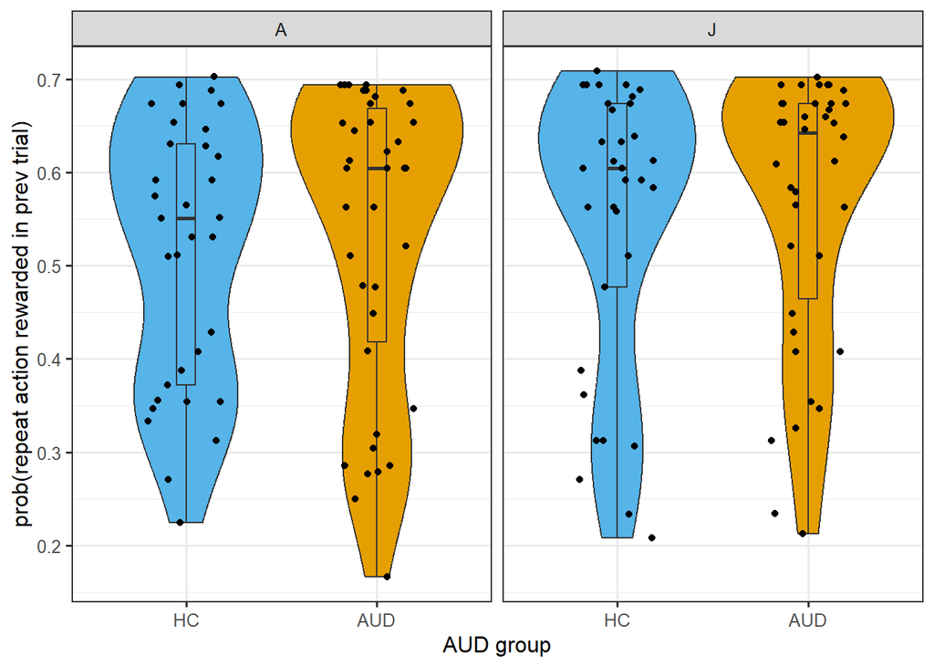

```r
fig4 <- ggplot(df_win_stay, aes(aud_group, y = win_stay_p, fill=aud_group)) +
  geom_violin() +
  geom_boxplot(width=0.1) +
  geom_jitter(shape=16, position=position_jitter(0.2)) +
  facet_wrap(~ reinforcer_type, scales="fixed") +
  scale_x_discrete("AUD group", labels=c('HC', 'AUD')) +
  scale_y_continuous("prob(repeat action rewarded in prev trial)") +
  scale_fill_manual("AUD_group", values = cbPalette[c(6,8)]) +
  theme_bw(base_size=12) +
  theme(legend.position = "none")

fig4
```

### 6.4.2 Violin plot per AUD group

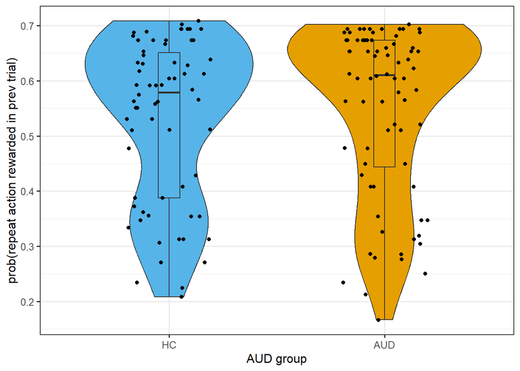

```r
fig5 <- ggplot(df_win_stay, aes(aud_group, y = win_stay_p, fill=aud_group)) +
  geom_violin() +
  geom_boxplot(width=0.1) +
  geom_jitter(shape=16, position=position_jitter(0.2)) +
  scale_x_discrete("AUD group", labels=c('HC', 'AUD')) +
  scale_y_continuous("prob(repeat action rewarded in prev trial)") +
  scale_fill_manual("AUD_group", values = cbPalette[c(6,8)]) +
  theme_bw(base_size=12) +
  theme(legend.position = "none")

fig5
```

### 6.4.3 Violin plot per reinforcer type

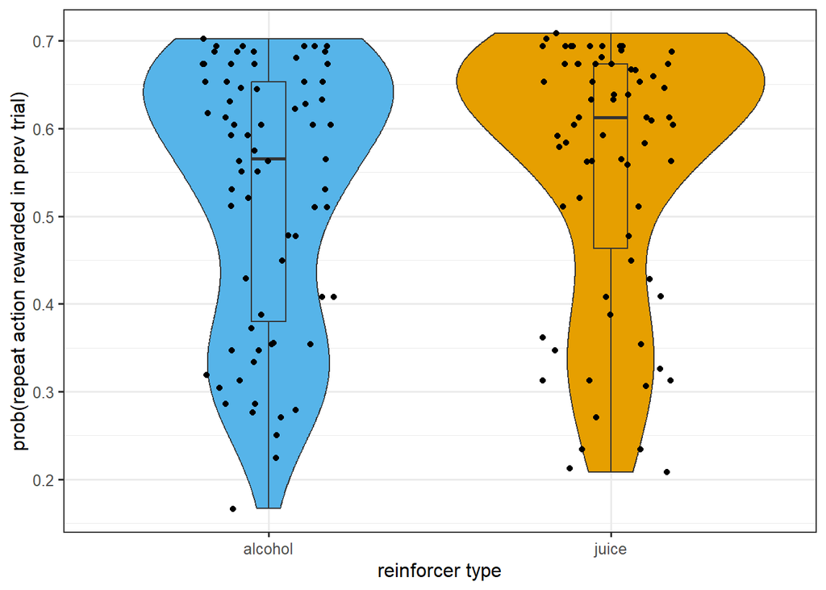

```r
fig6 <- ggplot(df_win_stay, aes(reinforcer_type, y = win_stay_p, fill=reinforcer_type)) +
  geom_violin() +
  geom_boxplot(width=0.1) +
  geom_jitter(shape=16, position=position_jitter(0.2)) +
  scale_x_discrete("reinforcer type", labels=c('alcohol', 'juice')) +
  scale_y_continuous("prob(repeat action rewarded in prev trial)") +
  scale_fill_manual("reinforcer_type", values = cbPalette[c(6,8)]) +
  theme_bw(base_size=12) +
  theme(legend.position = "none")

fig6
```

### 6.4.4 Win-stay behavior over course of task

#### 6.4.4.1 Per block

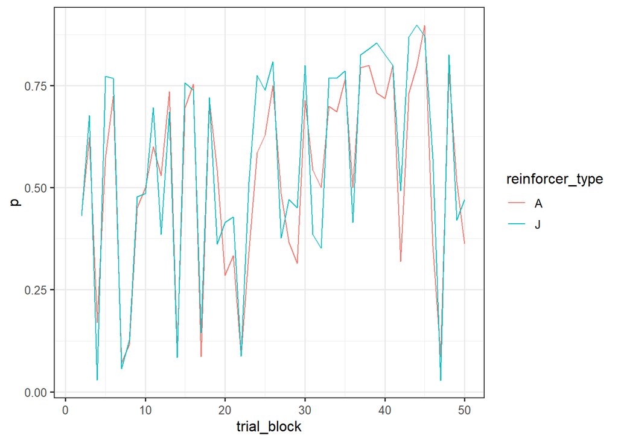

```r
fig2 <- ggplot(df_win_stay_trial, aes(x=trial_block, y=p, group=reinforcer_type)) +
  geom_line(aes(color=reinforcer_type)) +
  scale_fill_manual("Reinforcer type", values = cbPalette[c(1,2)]) +
  theme_bw(base_size=12)

fig2
```

#### 6.4.4.2 Per block and aud group

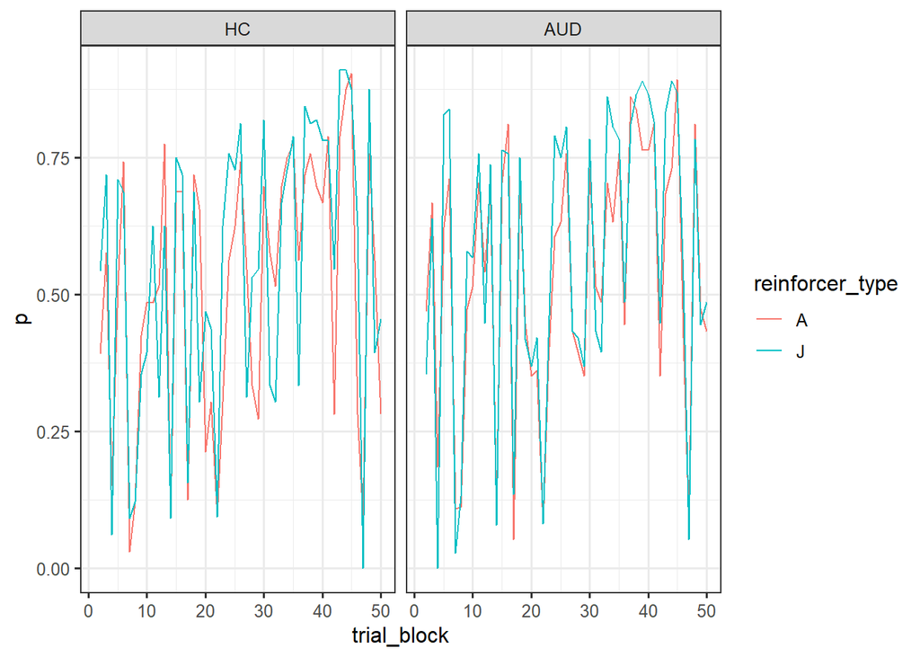

```r
fig3 <- ggplot(df_win_stay_trial_group, aes(x=trial_block, y=p, group=reinforcer_type)) +
  geom_line(aes(color=reinforcer_type)) +
  scale_fill_manual("Reinforcer type", values = cbPalette[c(1,2)]) +
  theme_bw(base_size=12) +
  facet_wrap(~aud_group, scales="fixed")

fig3
```

# 7 No-Win-Switch behavior: Switching the action if it was not rewarded in previous trial

## 7.1 Prepare dfs

```r
# get p correct per subject and block for linear mixed-effects regression
df_nowin_switch <- behav_final %>%
  group_by(ID,reinforcer_type,na.rm=T) %>%
  summarise_at(vars(stay,nowin_switch), list(p = mean), na.rm=T) %>%
  na.omit()
df_nowin_switch <- merge(df_nowin_switch,redcap,by="ID") # merge with demographic data for linear mixed-effects

# get p correct per block and trial for plotting
df_nowin_switch_trial <- behav_final %>%
  group_by(reinforcer_type,trial_block) %>%
  summarise_at(vars(nowin_switch), list(p = mean), na.rm=T)

# get p correct per block and aud group and trial for plotting
df_nowin_switch_trial_group <- behav_final_redcap %>%
  group_by(aud_group,reinforcer_type,trial_block) %>%
  summarise_at(vars(nowin_switch), list(p = mean), na.rm=T)
```

## 7.2 Linear mixed-effects regression

### 7.2.1 AUD group

```r
m_nowin_switch_1=lmer(nowin_switch_p~reinforcer_type*aud_group + (1 | ID),
                data=df_nowin_switch,
                control=lmerControl(calc.derivs=FALSE))
#m_nowin_switch_2=lmer(nowin_switch_p~reinforcer_type*aud_group + (1 + reinforcer_type || ID),
#                data=df_nowin_switch,
#                control=lmerControl(calc.derivs=FALSE))
#m_nowin_switch_3=lmer(nowin_switch_p~reinforcer_type*aud_group + (1 + reinforcer_type | ID),
#                data=df_nowin_switch,
#                control=lmerControl(calc.derivs=FALSE))
#anova(m_nowin_switch_1,m_nowin_switch_2,m_nowin_switch_3)

tab_model(m_nowin_switch_1,
          dv.labels=c("m_switch"), digits=3, digits.re=2,
          show.se=TRUE, show.stat=TRUE, show.df=TRUE, show.ci=FALSE,CSS = css_theme("cells"))
```

|  | m_switch |  |  |  |  |
| --- | --- | --- | --- | --- | --- |
| Predictors | Estimates | std. Error | Statistic | p | df |
| (Intercept) | 0.116 | 0.018 | 6.352 | **<0.001** | 136.000 |
| reinforcer type2 | -0.002 | 0.015 | -0.130 | 0.897 | 136.000 |
| aud group2 | 0.003 | 0.025 | 0.108 | 0.914 | 136.000 |
| reinforcer type2 × aud group2 | -0.018 | 0.020 | -0.916 | 0.361 | 136.000 |
| Random Effects |  |  |  |  |  |
| σ<sup>2</sup> | 0.00 |  |  |  |  |
| τ<sub>00</sub> <sub>ID</sub> | 0.01 |  |  |  |  |
| ICC | 0.68 |  |  |  |  |
| N <sub>ID</sub> | 71 |  |  |  |  |
| Observations | 142 |  |  |  |  |
| Marginal R<sup>2</sup> / Conditional R<sup>2</sup> | 0.006 / 0.683 |  |  |  |  |

### 7.2.2 AUD criteria

```r
m_nowin_switch_1_audsum=lmer(nowin_switch_p~reinforcer_type*aud_sum + (1 | ID),
                data=df_nowin_switch,
                control=lmerControl(calc.derivs=FALSE))
#m_win_stay_2_audsum=lmer(win_stay_p~reinforcer_type*aud_sum + (1 + reinforcer_type || ID),
#                data=df_win_stay,
#                control=lmerControl(calc.derivs=FALSE))
#m_win_stay_3_audsum=lmer(win_stay_p~reinforcer_type*aud_sum + (1 + reinforcer_type | ID),
#                data=df_win_stay,
#                control=lmerControl(calc.derivs=FALSE))
#anova(m_win_stay_1_audsum,m_win_stay_2_audsum,m_win_stay_3_audsum)

tab_model(m_nowin_switch_1_audsum,
          dv.labels=c("m_switch"), digits=3, digits.re=2,
          show.se=TRUE, show.stat=TRUE, show.df=TRUE, show.ci=FALSE,CSS = css_theme("cells"))
```

|  | m_switch |  |  |  |  |
| --- | --- | --- | --- | --- | --- |
| Predictors | Estimates | std. Error | Statistic | p | df |
| (Intercept) | 0.117 | 0.018 | 6.615 | **<0.001** | 136.000 |
| reinforcer type2 | -0.004 | 0.014 | -0.307 | 0.760 | 136.000 |
| aud sum | 0.000 | 0.005 | 0.037 | 0.971 | 136.000 |
| reinforcer type2 × aud sum | -0.003 | 0.004 | -0.730 | 0.466 | 136.000 |
| Random Effects |  |  |  |  |  |
| σ<sup>2</sup> | 0.00 |  |  |  |  |
| τ<sub>00</sub> <sub>ID</sub> | 0.01 |  |  |  |  |
| ICC | 0.68 |  |  |  |  |
| N <sub>ID</sub> | 71 |  |  |  |  |
| Observations | 142 |  |  |  |  |
| Marginal R<sup>2</sup> / Conditional R<sup>2</sup> | 0.005 / 0.682 |  |  |  |  |

### 7.2.3 AUDIT criteria

```r
m_nowin_switch_1_auditsum=lmer(nowin_switch_p~reinforcer_type*audit_sum + (1 | ID),
                data=df_nowin_switch,
                control=lmerControl(calc.derivs=FALSE))
#m_nowin_switch_2_auditsum=lmer(nowin_switch_p~reinforcer_type*audit_sum + (1 + reinforcer_type || ID),
#                data=df_nowin_switch,
#                control=lmerControl(calc.derivs=FALSE))
#m_nowin_switch_3_auditsum=lmer(nowin_switch_p~reinforcer_type*audit_sum + (1 + reinforcer_type | ID),
#                data=df_nowin_switch,
#                control=lmerControl(calc.derivs=FALSE))
#anova(m_nowin_switch_1_auditsum,m_nowin_switch_2_auditsum,m_nowin_switch_3_auditsum)

tab_model(m_nowin_switch_1_auditsum,
          dv.labels=c("m_switch"), digits=3, digits.re=2,
          show.se=TRUE, show.stat=TRUE, show.df=TRUE, show.ci=FALSE,CSS = css_theme("cells"))
```

|  | m_switch |  |  |  |  |
| --- | --- | --- | --- | --- | --- |
| Predictors | Estimates | std. Error | Statistic | p | df |
| (Intercept) | 0.121 | 0.022 | 5.625 | **<0.001** | 136.000 |
| reinforcer type2 | -0.013 | 0.017 | -0.764 | 0.446 | 136.000 |
| audit sum | -0.000 | 0.002 | -0.211 | 0.833 | 136.000 |
| reinforcer type2 × audit sum | 0.000 | 0.002 | 0.108 | 0.914 | 136.000 |
| Random Effects |  |  |  |  |  |
| σ<sup>2</sup> | 0.00 |  |  |  |  |
| τ<sub>00</sub> <sub>ID</sub> | 0.01 |  |  |  |  |
| ICC | 0.68 |  |  |  |  |
| N <sub>ID</sub> | 71 |  |  |  |  |
| Observations | 142 |  |  |  |  |
| Marginal R<sup>2</sup> / Conditional R<sup>2</sup> | 0.004 / 0.679 |  |  |  |  |